# R markdown test

BVD

9/18/2018

First we need to build the HLM models in R (done) Then do the AIC testing (not possible. We’ll do a simple variance explained argument) Then do assumption checking Then build descriptives for gain aggregated and disagregated and add the means to the descriptives table

Load stuff (There are some packages that we don’t need here, but I didn’t clean them up. Sorry.)

```r
#load("~/Box Sync/work/Research/R stuff/hmiout40") #Ben's computer
load("~/Documents/LASSO Data/Old/hmiout40")
library(tidyr)
library("ggplot2")
library(gvlma)
library("HLMdiag")
library("DHARMa")
library("car") #for the Levene test which we will not discuss here
library("Matrix")
library(mitools)
library(stargazer)
library(lme4)
library(nlme)
library(mice)
library(mitml)
library(multcomp)
library(foreach)
library(ggplot2)
library(stringr)
library(dplyr)  #I load dplyr last because some of its functions (select) will be masked by plyr and it is a PITA to debug
```

Creating mitml and extra variables

```r
MIdata<-mids2mitml.list(hmi.out40) #converts file type

thing <- list()
for (i in 1:10){
  temp <- MIdata[[i]]
  class_means <- temp %>% group_by(crse_id) %>% summarise(pre_mean_class = mean(pre_scor))
  class_means$class_pre_cent <- class_means$pre_mean_class - mean(class_means$pre_mean_class)
  temp <- left_join(temp,class_means, by="crse_id")
  temp$stud_pre_cent <- temp$pre_scor - temp$pre_mean_class
  temp$stud_pre_grand <- temp$pre_scor-mean(temp$pre_scor)
  temp$gain <- temp$pst_scor - temp$pre_scor
  temp$collabnla <- ifelse(temp$colablrn==1,ifelse(temp$used_las==0,1,0),0)
  temp$coll <- temp$collabnla + temp$used_las
  #assign(df.names[i], temp)
  thing[[i]] <- temp
  }
MIdata <- as.mitml.list(thing)
```

Models (Note, we can’t actually use these since they don’t work with the with function)

```r
mod1 <- (gain~1 + (1|crse_id))
mod2 <- (gain~1 + used_las + collabnla + (1|crse_id))
mod3 <- (gain~1 + stud_pre_cent+  used_las + collabnla + (1|crse_id))
mod4 <- (gain~1 + stud_pre_cent+  used_las + collabnla + (1+ stud_pre_cent|crse_id))
mod5 <- (gain~1 + stud_pre_cent+  used_las + collabnla + class_pre_cent + (1|crse_id))
mod6 <- (gain~1 + stud_pre_cent+  used_las + collabnla + class_pre_cent + (1+ stud_pre_cent|crse_id))
mod7 <- (gain~1 + stud_pre_cent+  used_las + collabnla + FMCE + (1|crse_id))
mod8 <- (gain~1 + stud_pre_cent+  used_las + collabnla + fst_time + (1|crse_id))
```

Run HLM models

```r
HLM1<-with(MIdata,{lmer(gain~1 + (1|crse_id))})
HLM1.1<-with(MIdata,{lmer(gain~1 +  stud_pre_cent + (1|crse_id))})
HLM1.2<-with(MIdata,{lmer(gain~1 +  stud_pre_cent + class_pre_cent + (1|crse_id))})
HLM2<-with(MIdata,{lmer(gain~1 + used_las + collabnla + (1|crse_id))})
HLM3<-with(MIdata,{lmer(gain~1 + stud_pre_cent+  used_las + collabnla + (1|crse_id))})
HLM4<-with(MIdata,{lmer(gain~1 + stud_pre_cent+  used_las + collabnla + (1+ stud_pre_cent|crse_id))})
HLM5<-with(MIdata,{lmer(gain~1 + stud_pre_cent+  used_las + collabnla + class_pre_cent + (1|crse_id))})
HLM6<-with(MIdata,{lmer(gain~1 + stud_pre_cent+  used_las + collabnla + class_pre_cent + (1+ stud_pre_cent|crse_id))})
HLM7 <- with(MIdata,{lmer(gain~1 + stud_pre_cent+  used_las + collabnla + FMCE + (1|crse_id))})
HLM8 <- with(MIdata,{lmer(gain~1 + stud_pre_cent+  used_las + collabnla + fst_time + (1|crse_id))})
```

Run MLR models

```r
MLR1<-with(MIdata,{lm(gain~1)})
MLR2<-with(MIdata,{lm(gain~1 + used_las + collabnla)})
MLR3<-with(MIdata,{lm(gain~1 + stud_pre_cent+  used_las + collabnla)})
MLR4<-with(MIdata,{lm(gain~1 + stud_pre_cent+  used_las + collabnla)})
MLR5<-with(MIdata,{lm(gain~1 + stud_pre_cent+  used_las + collabnla + class_pre_cent)})
MLR6<-with(MIdata,{lm(gain~1 + stud_pre_cent+  used_las + collabnla + class_pre_cent)})
```

HLM Model outputs

```r
testEstimates(HLM1, var.comp=TRUE)
```

```
##
## Call:
##
## testEstimates(model = HLM1, var.comp = TRUE)
##
## Final parameter estimates and inferences obtained from 10 imputed data sets.
##
##              Estimate Std.Error   t.value        df   P(>|t|)       RIV       FMI
## (Intercept)    18.284     0.872    20.977   669.237     0.000     0.131     0.119
##
##                              Estimate
## Intercept~~Intercept|crse_id   60.620
## Residual~~Residual            409.799
## ICC|crse_id                     0.129
##
## Unadjusted hypothesis test as appropriate in larger samples.
```

```r
testEstimates(HLM2, var.comp=TRUE)
```

```
##
## Call:
##
## testEstimates(model = HLM2, var.comp = TRUE)
##
## Final parameter estimates and inferences obtained from 10 imputed data sets.
##
##              Estimate Std.Error   t.value        df   P(>|t|)       RIV       FMI
## (Intercept)    13.696     2.131     6.428   891.880     0.000     0.112     0.102
## used_las        6.014     2.352     2.557  1215.587     0.011     0.094     0.088
## collabnla       3.512     3.008     1.168   269.731     0.244     0.223     0.189
##
##                              Estimate
## Intercept~~Intercept|crse_id   56.570
## Residual~~Residual            409.830
## ICC|crse_id                     0.121
##
## Unadjusted hypothesis test as appropriate in larger samples.
```

```r
testEstimates(HLM3, var.comp=TRUE)
```

```
##
## Call:
##
## testEstimates(model = HLM3, var.comp = TRUE)
##
## Final parameter estimates and inferences obtained from 10 imputed data sets.
##
##                Estimate Std.Error   t.value        df   P(>|t|)       RIV       FMI
## (Intercept)      13.760     2.144     6.419   812.980     0.000     0.118     0.107
## stud_pre_cent    -0.440     0.023   -18.844    19.165     0.000     2.177     0.714
## used_las          5.936     2.363     2.512  1160.173     0.012     0.097     0.090
## collabnla         3.256     3.023     1.077   247.880     0.283     0.235     0.197
##
##                              Estimate
## Intercept~~Intercept|crse_id   58.827
## Residual~~Residual            343.497
## ICC|crse_id                     0.146
##
## Unadjusted hypothesis test as appropriate in larger samples.
```

```r
testEstimates(HLM4, var.comp=TRUE)
```

```
##
## Call:
##
## testEstimates(model = HLM4, var.comp = TRUE)
##
## Final parameter estimates and inferences obtained from 10 imputed data sets.
##
##                Estimate Std.Error   t.value        df   P(>|t|)       RIV       FMI
## (Intercept)      13.347     2.052     6.505  1402.821     0.000     0.087     0.081
## stud_pre_cent    -0.426     0.025   -16.833    33.212     0.000     1.086     0.547
## used_las          6.662     2.289     2.911   951.554     0.004     0.108     0.099
## collabnla         2.952     2.951     1.001   201.237     0.318     0.268     0.219
##
##                                      Estimate
## Intercept~~Intercept|crse_id           58.825
## Intercept~~stud_pre_cent|crse_id       -0.437
## stud_pre_cent~~stud_pre_cent|crse_id    0.009
## Residual~~Residual                    340.331
## ICC|crse_id                             0.147
##
## Unadjusted hypothesis test as appropriate in larger samples.
```

```r
testEstimates(HLM5, var.comp=TRUE)
```

```
##
## Call:
##
## testEstimates(model = HLM5, var.comp = TRUE)
##
## Final parameter estimates and inferences obtained from 10 imputed data sets.
##
##                 Estimate Std.Error   t.value        df   P(>|t|)       RIV       FMI
## (Intercept)       13.659     2.209     6.184  1545.906     0.000     0.083     0.077
## stud_pre_cent     -0.440     0.023   -18.844    19.165     0.000     2.177     0.714
## used_las           6.036     2.445     2.469  1426.050     0.014     0.086     0.081
## collabnla          3.388     3.135     1.081   306.195     0.281     0.207     0.177
## class_pre_cent    -0.015     0.098    -0.158   337.055     0.874     0.195     0.168
##
##                              Estimate
## Intercept~~Intercept|crse_id   59.394
## Residual~~Residual            343.494
## ICC|crse_id                     0.147
##
## Unadjusted hypothesis test as appropriate in larger samples.
```

```r
testEstimates(HLM6, var.comp=TRUE)
```

```
##
## Call:
##
## testEstimates(model = HLM6, var.comp = TRUE)
##
## Final parameter estimates and inferences obtained from 10 imputed data sets.
##
##                 Estimate Std.Error   t.value        df   P(>|t|)       RIV       FMI
## (Intercept)       12.932     2.122     6.093  2448.292     0.000     0.065     0.061
## stud_pre_cent     -0.426     0.025   -16.876    33.600     0.000     1.073     0.544
## used_las           7.091     2.405     2.948   636.825     0.003     0.135     0.122
## collabnla          3.493     3.032     1.152   279.903     0.250     0.218     0.185
## class_pre_cent    -0.060     0.096    -0.623   218.294     0.534     0.255     0.210
##
##                                      Estimate
## Intercept~~Intercept|crse_id           59.644
## Intercept~~stud_pre_cent|crse_id       -0.455
## stud_pre_cent~~stud_pre_cent|crse_id    0.009
## Residual~~Residual                    340.323
## ICC|crse_id                             0.149
##
## Unadjusted hypothesis test as appropriate in larger samples.
```

```r
testEstimates(HLM7, var.comp=TRUE)
```

```
##
## Call:
##
## testEstimates(model = HLM7, var.comp = TRUE)
##
## Final parameter estimates and inferences obtained from 10 imputed data sets.
##
##                Estimate Std.Error   t.value        df   P(>|t|)       RIV       FMI
## (Intercept)      13.715     2.160     6.349   769.754     0.000     0.121     0.110
## stud_pre_cent    -0.440     0.023   -18.844    19.165     0.000     2.177     0.714
## used_las          5.789     2.398     2.414  1269.656     0.016     0.092     0.086
## collabnla         3.194     3.031     1.054   259.469     0.293     0.229     0.192
## FMCE              0.821     2.153     0.381  4056.408     0.703     0.049     0.048
##
##                              Estimate
## Intercept~~Intercept|crse_id   59.400
## Residual~~Residual            343.493
## ICC|crse_id                     0.147
##
## Unadjusted hypothesis test as appropriate in larger samples.
```

```r
testEstimates(HLM8, var.comp=TRUE)
```

```
##
## Call:
##
## testEstimates(model = HLM8, var.comp = TRUE)
##
## Final parameter estimates and inferences obtained from 10 imputed data sets.
##
##                Estimate Std.Error   t.value        df   P(>|t|)       RIV       FMI
## (Intercept)      10.995     2.169     5.069   943.235     0.000     0.108     0.100
## stud_pre_cent    -0.436     0.023   -18.717    19.150     0.000     2.180     0.714
## used_las          5.172     2.351     2.200   944.587     0.028     0.108     0.100
## collabnla         2.467     3.007     0.820   227.714     0.413     0.248     0.206
## fst_time          4.244     0.892     4.756    88.991     0.000     0.466     0.333
##
##                              Estimate
## Intercept~~Intercept|crse_id   57.251
## Residual~~Residual            341.744
## ICC|crse_id                     0.143
##
## Unadjusted hypothesis test as appropriate in larger samples.
```

MLR Model outputs

```r
testEstimates(MLR1, var.comp=TRUE)
```

```
##
## Call:
##
## testEstimates(model = MLR1, var.comp = TRUE)
##
## Final parameter estimates and inferences obtained from 10 imputed data sets.
##
##              Estimate Std.Error   t.value        df   P(>|t|)       RIV       FMI
## (Intercept)    19.337     0.343    56.366    81.196     0.000     0.499     0.349
##
##                    Estimate
## Residual~~Residual  467.805
##
## Unadjusted hypothesis test as appropriate in larger samples.
```

```r
testEstimates(MLR2, var.comp=TRUE)
```

```
##
## Call:
##
## testEstimates(model = MLR2, var.comp = TRUE)
##
## Final parameter estimates and inferences obtained from 10 imputed data sets.
##
##              Estimate Std.Error   t.value        df   P(>|t|)       RIV       FMI
## (Intercept)    12.009     0.993    12.089    51.731     0.000     0.716     0.438
## used_las        7.266     1.063     6.836    58.355     0.000     0.647     0.413
## collabnla      12.990     1.340     9.694    45.976     0.000     0.794     0.465
##
##                    Estimate
## Residual~~Residual  454.978
##
## Unadjusted hypothesis test as appropriate in larger samples.
```

```r
testEstimates(MLR3, var.comp=TRUE)
```

```
##
## Call:
##
## testEstimates(model = MLR3, var.comp = TRUE)
##
## Final parameter estimates and inferences obtained from 10 imputed data sets.
##
##                Estimate Std.Error   t.value        df   P(>|t|)       RIV       FMI
## (Intercept)      12.009     0.951    12.627    43.459     0.000     0.835     0.479
## stud_pre_cent    -0.440     0.024   -18.456    20.828     0.000     1.918     0.686
## used_las          7.266     1.016     7.154    48.651     0.000     0.755     0.452
## collabnla        12.990     1.285    10.106    38.930     0.000     0.926     0.506
##
##                    Estimate
## Residual~~Residual  389.853
##
## Unadjusted hypothesis test as appropriate in larger samples.
```

```r
testEstimates(MLR4, var.comp=TRUE)
```

```
##
## Call:
##
## testEstimates(model = MLR4, var.comp = TRUE)
##
## Final parameter estimates and inferences obtained from 10 imputed data sets.
##
##                Estimate Std.Error   t.value        df   P(>|t|)       RIV       FMI
## (Intercept)      12.009     0.951    12.627    43.459     0.000     0.835     0.479
## stud_pre_cent    -0.440     0.024   -18.456    20.828     0.000     1.918     0.686
## used_las          7.266     1.016     7.154    48.651     0.000     0.755     0.452
## collabnla        12.990     1.285    10.106    38.930     0.000     0.926     0.506
##
##                    Estimate
## Residual~~Residual  389.853
##
## Unadjusted hypothesis test as appropriate in larger samples.
```

```r
testEstimates(MLR5, var.comp=TRUE)
```

```
##
## Call:
##
## testEstimates(model = MLR5, var.comp = TRUE)
##
## Final parameter estimates and inferences obtained from 10 imputed data sets.
##
##                 Estimate Std.Error   t.value        df   P(>|t|)       RIV       FMI
## (Intercept)       12.392     1.014    12.226    41.175     0.000     0.878     0.492
## stud_pre_cent     -0.440     0.024   -18.457    20.823     0.000     1.919     0.686
## used_las           6.915     1.077     6.421    43.681     0.000     0.831     0.477
## collabnla         12.427     1.408     8.827    34.829     0.000     1.034     0.534
## class_pre_cent     0.050     0.035     1.435   160.813     0.153     0.310     0.246
##
##                    Estimate
## Residual~~Residual  389.726
##
## Unadjusted hypothesis test as appropriate in larger samples.
```

```r
testEstimates(MLR6, var.comp=TRUE)
```

```
##
## Call:
##
## testEstimates(model = MLR6, var.comp = TRUE)
##
## Final parameter estimates and inferences obtained from 10 imputed data sets.
##
##                 Estimate Std.Error   t.value        df   P(>|t|)       RIV       FMI
## (Intercept)       12.392     1.014    12.226    41.175     0.000     0.878     0.492
## stud_pre_cent     -0.440     0.024   -18.457    20.823     0.000     1.919     0.686
## used_las           6.915     1.077     6.421    43.681     0.000     0.831     0.477
## collabnla         12.427     1.408     8.827    34.829     0.000     1.034     0.534
## class_pre_cent     0.050     0.035     1.435   160.813     0.153     0.310     0.246
##
##                    Estimate
## Residual~~Residual  389.726
##
## Unadjusted hypothesis test as appropriate in larger samples.
```

Assumption checking as recommended here: https://ademos.people.uic.edu/Chapter18.html Note: I think we may just need to do this for each of the 10 datasets independently.

```r
D1 <- lmer(mod3,data=MIdata[[1]])
```

Assumption checking code to be done for all 10 datasets

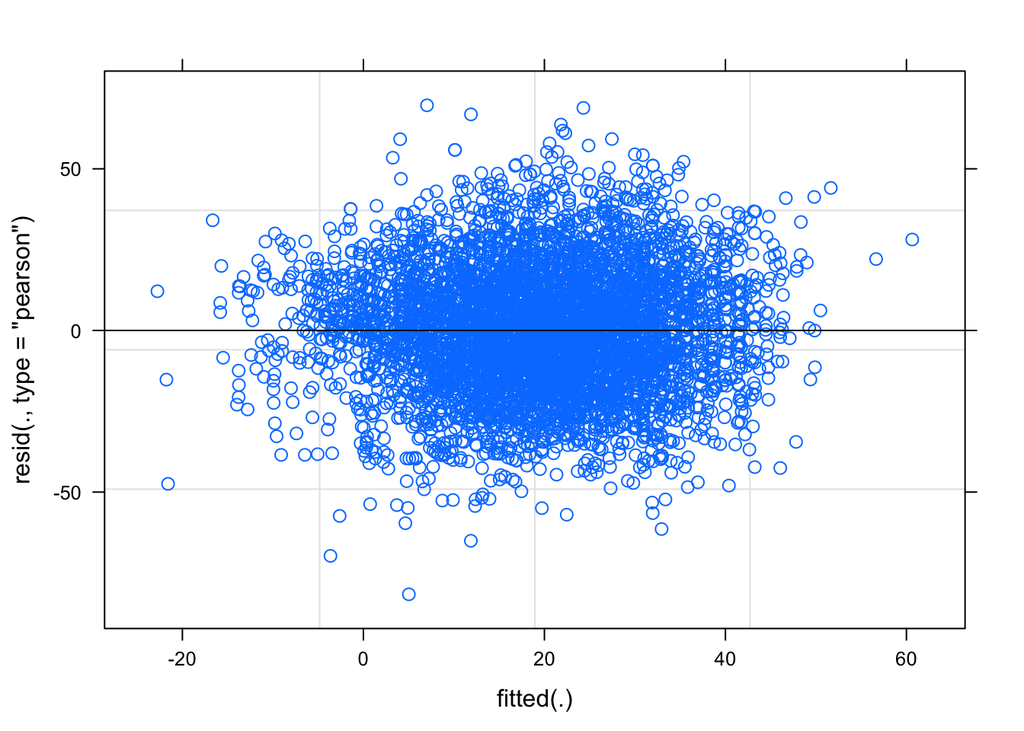

```r
#linearity: Shouldn't see a pattern
plot(D1)
```

```r
#variables are not correlated to the residuals: want a p-value>0.05
cor.test(resid(D1), MIdata[[1]]$pre_scor)
```

```
##
##  Pearson's product-moment correlation
##
## data:  resid(D1) and MIdata[[1]]$pre_scor
## t = 0.036379, df = 5957, p-value = 0.971
## alternative hypothesis: true correlation is not equal to 0
## 95 percent confidence interval:
##  -0.02491982  0.02586189
## sample estimates:
##          cor
## 0.0004713377
```

```r
cor.test(resid(D1), MIdata[[1]]$stud_pre_cent)
```

```
##
##  Pearson's product-moment correlation
##
## data:  resid(D1) and MIdata[[1]]$stud_pre_cent
## t = -3.7072e-14, df = 5957, p-value = 1
## alternative hypothesis: true correlation is not equal to 0
## 95 percent confidence interval:
##  -0.02539086  0.02539086
## sample estimates:
##           cor
## -4.803239e-16
```

```r
#quantitative homogeneity of variance
MIdata[[1]]$Model.F.Res<- residuals(D1) #extracts the residuals and places them in a new column in our original data table
MIdata[[1]]$Abs.Model.F.Res <-abs(MIdata[[1]]$Model.F.Res) #creates a new column with the absolute value of the residuals
#MIdata[[1]]$Model.F.Res2 <- MIdata[[1]]$Abs.Model.F.Res^2 #squares the absolute values of the residuals to provide the more robust estimate

Levene.Model.F <- lm(Model.F.Res ~ crse_id, data=MIdata[[1]]) #ANOVA of the residuals
anova(Levene.Model.F) #displays the results: want a p>0.05
```

```
## Analysis of Variance Table
##
## Response: Model.F.Res
##             Df  Sum Sq Mean Sq F value Pr(>F)
## crse_id      1      47   46.98  0.1397 0.7085
## Residuals 5957 2002574  336.17
```

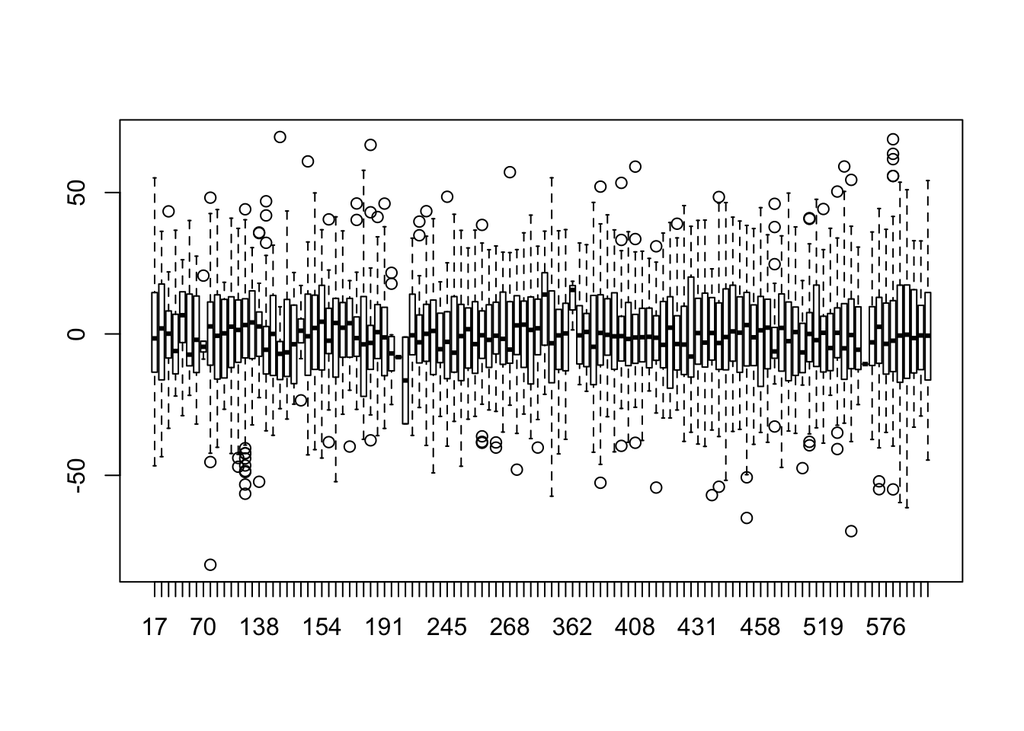

```r
#Levene.Model.F2 <- lm(Model.F.Res2 ~ crse_id, data=MIdata[[1]]) #ANOVA of the squared residuals
#anova(Levene.Model.F2) #displays the results

#visual homogeneity of variance
boxplot(MIdata[[1]]$Model.F.Res ~ MIdata[[1]]$crse_id)
```

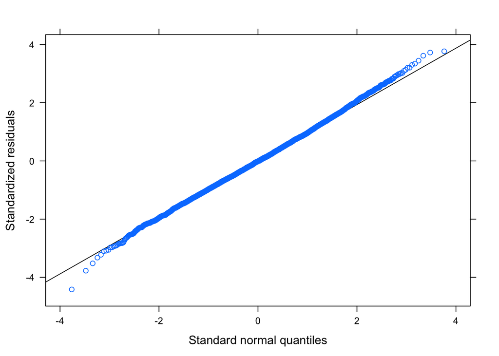

```r
#boxplot(MIdata[[1]]$Model.F.Res2 ~ MIdata[[1]]$crse_id)

#Assumption of Normality or residuals: want points to be near the line
qqmath(D1)
```

Linearity… check residuals following this guys solution? https://lib.dr.iastate.edu/cgi/viewcontent.cgi?article=4284&context=etd https://stackoverflow.com/questions/33859440/residual-plots-for-multiple-imputation-using-mice-package-in-r https://biologyforfun.wordpress.com/2014/04/16/checking-glm-model-assumptions-in-r/

Linearity (we pass)

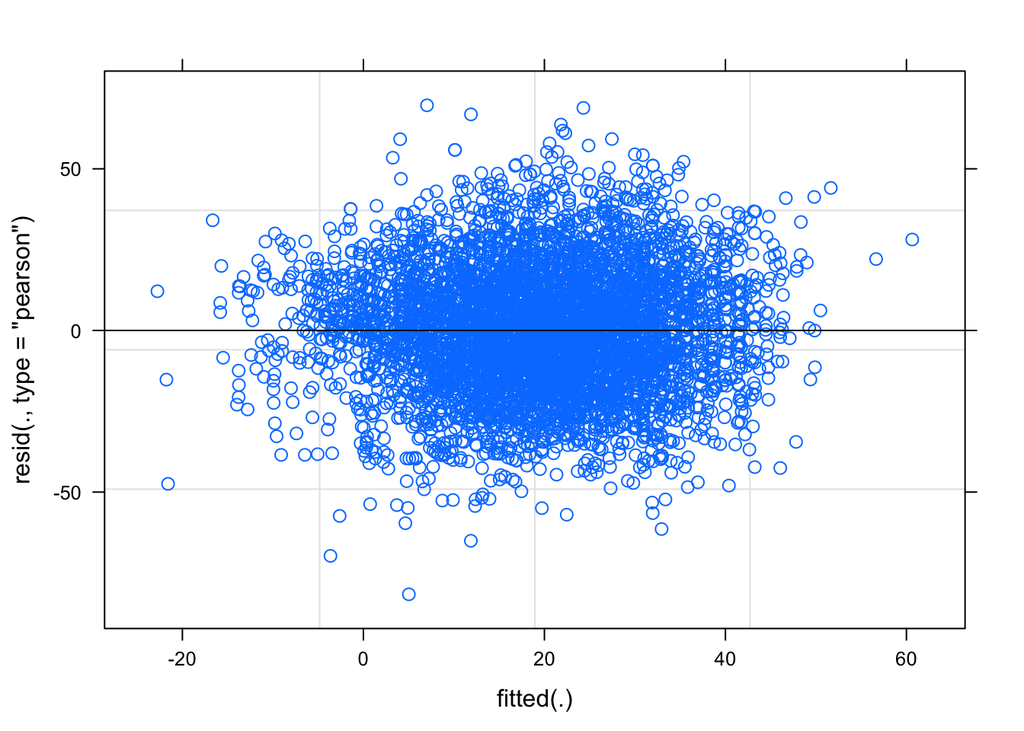

```r
plot(D1)
```

X variables are not correlated to the residuals (we pass)

```r
cor.test(resid(D1), MIdata[[1]]$pre_scor)
```

```
##
##  Pearson's product-moment correlation
##
## data:  resid(D1) and MIdata[[1]]$pre_scor
## t = 0.036379, df = 5957, p-value = 0.971
## alternative hypothesis: true correlation is not equal to 0
## 95 percent confidence interval:
##  -0.02491982  0.02586189
## sample estimates:
##          cor
## 0.0004713377
```

```r
cor.test(resid(D1), MIdata[[1]]$stud_pre_cent)
```

```
##
##  Pearson's product-moment correlation
##
## data:  resid(D1) and MIdata[[1]]$stud_pre_cent
## t = -3.7072e-14, df = 5957, p-value = 1
## alternative hypothesis: true correlation is not equal to 0
## 95 percent confidence interval:
##  -0.02539086  0.02539086
## sample estimates:
##           cor
## -4.803239e-16
```

```r
cor.test(resid(D1), MIdata[[1]]$used_las)
```

```
##
##  Pearson's product-moment correlation
##
## data:  resid(D1) and MIdata[[1]]$used_las
## t = 4.5456e-13, df = 5957, p-value = 1
## alternative hypothesis: true correlation is not equal to 0
## 95 percent confidence interval:
##  -0.02539086  0.02539086
## sample estimates:
##         cor
## 5.88948e-15
```

```r
cor.test(resid(D1), MIdata[[1]]$collabnla)
```

```
##
##  Pearson's product-moment correlation
##
## data:  resid(D1) and MIdata[[1]]$collabnla
## t = 1.8433e-14, df = 5957, p-value = 1
## alternative hypothesis: true correlation is not equal to 0
## 95 percent confidence interval:
##  -0.02539086  0.02539086
## sample estimates:
##          cor
## 2.388256e-16
```

https://ademos.people.uic.edu/Chapter18.html homogenety of variance we pass with variance, but not variance^2 (don’t pass?) Maybe not required for HLM: https://stats.stackexchange.com/questions/77891/checking-assumptions-lmer-lme-mixed-models-in-r https://stats.stackexchange.com/questions/255546/test-homogeneity-in-lmer-models

```r
MIdata[[1]]$Model.F.Res<- residuals(D1) #extracts the residuals and places them in a new column in our original data table
MIdata[[1]]$Abs.Model.F.Res <-abs(MIdata[[1]]$Model.F.Res) #creates a new column with the absolute value of the residuals
MIdata[[1]]$Model.F.Res2 <- MIdata[[1]]$Abs.Model.F.Res^2 #squares the absolute values of the residuals to provide the more robust estimate

Levene.Model.F <- lm(Model.F.Res ~ crse_id, data=MIdata[[1]]) #ANOVA of the residuals
anova(Levene.Model.F) #displays the results
```

```
## Analysis of Variance Table
##
## Response: Model.F.Res
##             Df  Sum Sq Mean Sq F value Pr(>F)
## crse_id      1      47   46.98  0.1397 0.7085
## Residuals 5957 2002574  336.17
```

```r
Levene.Model.F2 <- lm(Model.F.Res2 ~ crse_id, data=MIdata[[1]]) #ANOVA of the squared residuals
anova(Levene.Model.F2) #displays the results
```

```
## Analysis of Variance Table
##
## Response: Model.F.Res2
##             Df     Sum Sq Mean Sq F value   Pr(>F)
## crse_id      1    2682790 2682790  10.834 0.001003 **
## Residuals 5957 1475167082  247636
## ---
## Signif. codes:  0 '***' 0.001 '**' 0.01 '*' 0.05 '.' 0.1 ' ' 1
```

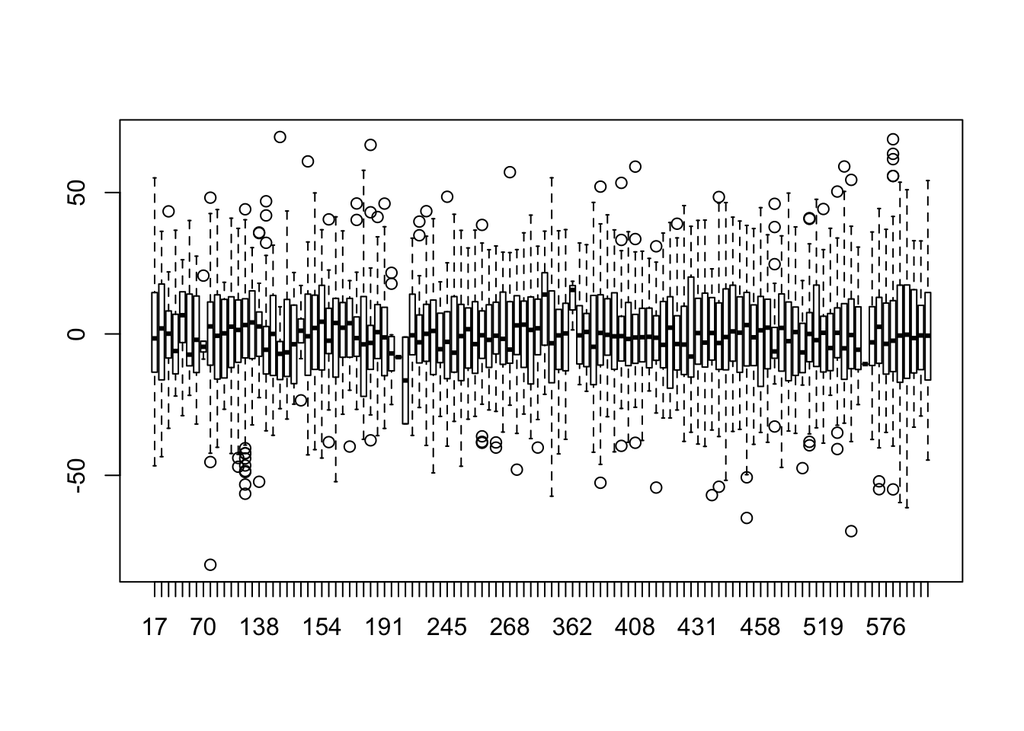

```r
boxplot(MIdata[[1]]$Model.F.Res ~ MIdata[[1]]$crse_id)
```

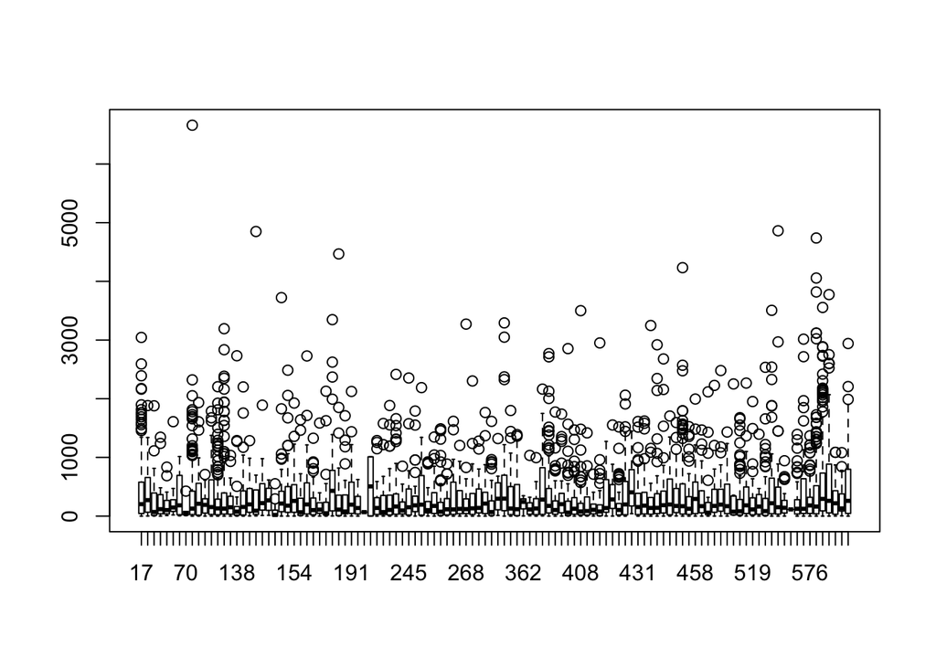

```r
boxplot(MIdata[[1]]$Model.F.Res2 ~ MIdata[[1]]$crse_id)
```

Assumption of Normality or residuals (we pass)

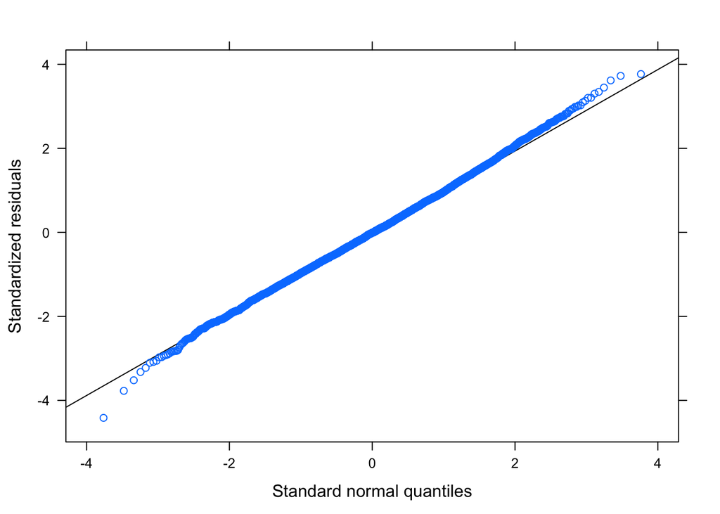

```r
qqmath(D1) #id: identifies values that may be exerting undue influence on the model (i.e. outliers)
```

Try using Dharma: https://cran.r-project.org/web/packages/DHARMa/vignettes/DHARMa.html

```r
simulationOutput <- with(MIdata[[1]],{simulateResiduals(fittedModel = D1, n = 250)})
```

```
## Model family was recoginzed or set as continous, but duplicate values were detected in the simulation - changing to integer residuals (see help for details)
```

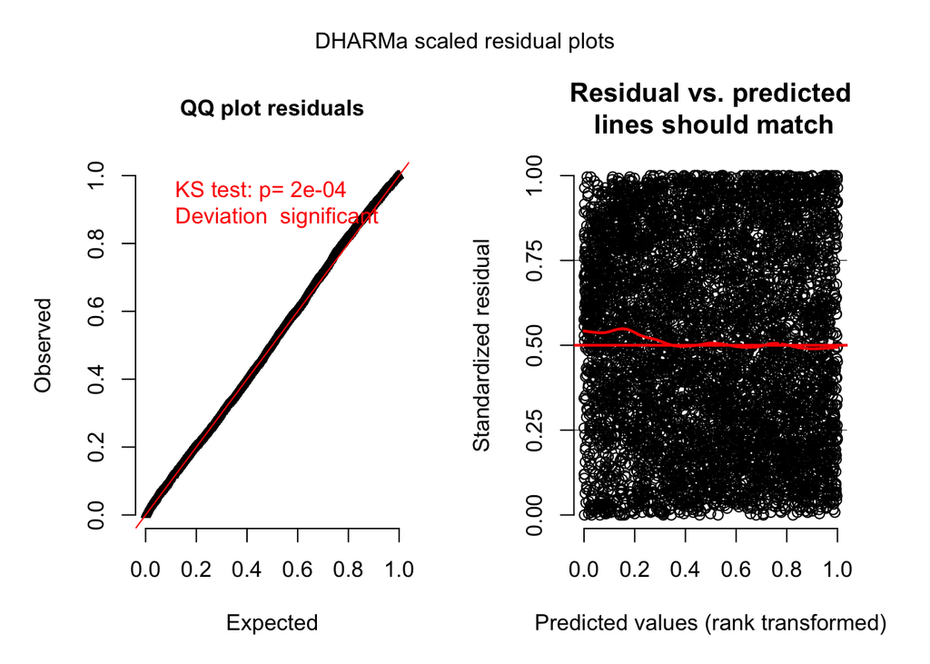

```r
plot(simulationOutput)
```

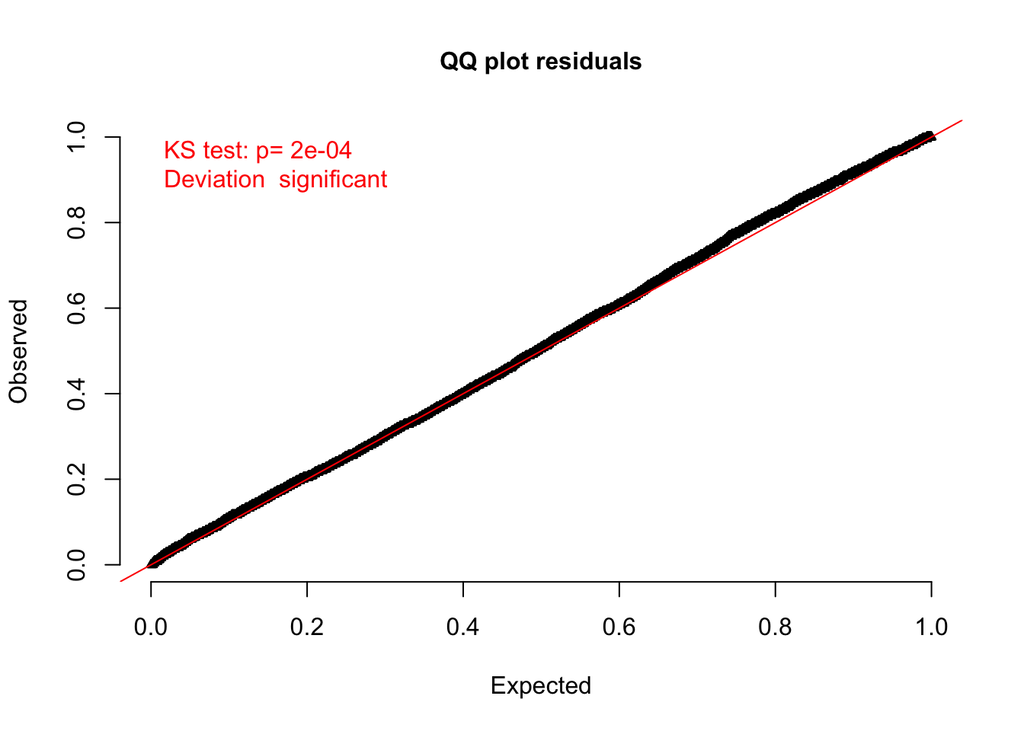

```
##
##  One-sample Kolmogorov-Smirnov test
##
## data:  simulationOutput$scaledResiduals
## D = 0.027775, p-value = 0.0002032
## alternative hypothesis: two-sided
```

```r
testUniformity(simulationOutput = simulationOutput)
```

http://r-statistics.co/Assumptions-of-Linear-Regression.html

Creating groups for final model

```r
testEstimates(HLM4, var.comp=TRUE)
```

```
##
## Call:
##
## testEstimates(model = HLM4, var.comp = TRUE)
##
## Final parameter estimates and inferences obtained from 10 imputed data sets.
##
##                Estimate Std.Error   t.value        df   P(>|t|)       RIV       FMI
## (Intercept)      13.347     2.052     6.505  1402.821     0.000     0.087     0.081
## stud_pre_cent    -0.426     0.025   -16.833    33.212     0.000     1.086     0.547
## used_las          6.662     2.289     2.911   951.554     0.004     0.108     0.099
## collabnla         2.952     2.951     1.001   201.237     0.318     0.268     0.219
##
##                                      Estimate
## Intercept~~Intercept|crse_id           58.825
## Intercept~~stud_pre_cent|crse_id       -0.437
## stud_pre_cent~~stud_pre_cent|crse_id    0.009
## Residual~~Residual                    340.331
## ICC|crse_id                             0.147
##
## Unadjusted hypothesis test as appropriate in larger samples.
```

```r
testEstimates(MLR3, var.comp=TRUE)
```

```
##
## Call:
##
## testEstimates(model = MLR3, var.comp = TRUE)
##
## Final parameter estimates and inferences obtained from 10 imputed data sets.
##
##                Estimate Std.Error   t.value        df   P(>|t|)       RIV       FMI
## (Intercept)      12.009     0.951    12.627    43.459     0.000     0.835     0.479
## stud_pre_cent    -0.440     0.024   -18.456    20.828     0.000     1.918     0.686
## used_las          7.266     1.016     7.154    48.651     0.000     0.755     0.452
## collabnla        12.990     1.285    10.106    38.930     0.000     0.926     0.506
##
##                    Estimate
## Residual~~Residual  389.853
##
## Unadjusted hypothesis test as appropriate in larger samples.
```

```r
Trad = c(1,0,0,0)
Collab = c(1,0,0,1)
LA = c(1,0,1,0)


HLM_preds <- rbind( 'Lecture'=Trad, 'Collaborative w/o LAs'=Collab,
                          'LAs'=LA)

Trad = c(1,0,0,0)
Collab = c(1,0,0,1)
LA = c(1,0,1,0)


HLM_preds <- rbind( 'Lecture'=Trad, 'Collaborative w/o LAs'=Collab,
                          'LAs'=LA)
```

```r
pool_and_cov_diffwm <- function(x,y){
  get.est <- foreach(i=1:10, .combine=rbind) %do% {
  sxp3 <- summary(glht(x[[i]], linfct=y)) #specifically for post3
  covp3 <- vcov(glht(x[[i]], linfct=y))
  data.frame(imp=i,
             group=rownames(sxp3$linfct),
             d = sxp3$test$coefficients,
             var.d = (sxp3$test$sigma)^2,
             cov = covp3)
}


p3est <- get.est %>% group_by(group) %>%
                  summarise(Q = mean(d),
                            U = mean(var.d),
                            B = var(d),
                            T = U + ((1+1/max(imp))*B),
                            LCL = Q - 1.96*sqrt(T),
                            UCL = Q + 1.96*sqrt(T),
                            SE = sqrt(T))
p3est$race <- word(p3est$group, 1)
p3est$gender <- word(p3est$group, 2)
p3est$instruction <- word(p3est$group, 3)
p3est$race_gender <- paste(p3est$race,p3est$gender, sep= " ")

return <- p3est}
```

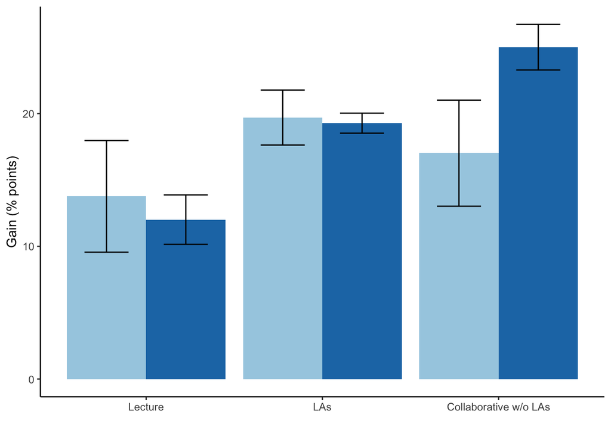

```r
HLM_models <- pool_and_cov_diffwm(HLM3,HLM_preds)
MLR_models <- pool_and_cov_diffwm(MLR3,HLM_preds)
HLM_models$test <- "HLM  "
MLR_models$test <- "MLR  "
HLM_MLR_est <- bind_rows(HLM_models,MLR_models)
HLM_MLR_est <- HLM_MLR_est[c(13,1,2,6,7)]
HLM_MLR_est$group <- factor(HLM_MLR_est$group, levels = c("Lecture","LAs","Collaborative w/o LAs"))

ggplot(HLM_MLR_est, aes(y=Q, x=group, fill=test )) +geom_bar(stat="identity", position = position_dodge(width=0.9)) + geom_errorbar(aes(ymax=UCL, ymin=LCL), position=position_dodge(0.9), width=0.5) + scale_fill_brewer(palette="Paired") +
  ylab("Gain (% points)") + xlab("") +
  theme(legend.position = c(0.36,-0.15), legend.direction = "horizontal", legend.title = element_blank(),panel.grid.major = element_blank(), panel.grid.minor = element_blank(),
panel.background = element_blank(), axis.line = element_line(colour = "black"))
```

# Centering analysis

The code below generates models to compare the three different methods for centering the prescores.

```r
HLM1.1.1<-with(MIdata,{lmer(gain~1 +  stud_pre_grand + (1|crse_id))})
HLM1.2.1<-with(MIdata,{lmer(gain~1 +  stud_pre_grand + class_pre_cent + (1|crse_id))})
HLM3.1<-with(MIdata,{lmer(gain~1 + stud_pre_grand+  used_las + collabnla + (1|crse_id))})
HLM4.1<-with(MIdata,{lmer(gain~1 + stud_pre_grand+  used_las + collabnla + (1+ stud_pre_grand|crse_id))})
HLM5.1<-with(MIdata,{lmer(gain~1 + stud_pre_grand+  used_las + collabnla + class_pre_cent + (1|crse_id))})
HLM6.1<-with(MIdata,{lmer(gain~1 + stud_pre_grand+  used_las + collabnla + class_pre_cent + (1+ stud_pre_cent|crse_id))})
```

```r
HLM1.1.2<-with(MIdata,{lmer(gain~1 +  pre_scor + (1|crse_id))})
HLM1.2.2<-with(MIdata,{lmer(gain~1 +  pre_scor + class_pre_cent + (1|crse_id))})
HLM3.2<-with(MIdata,{lmer(gain~1 + pre_scor+  used_las + collabnla + (1|crse_id))})
HLM4.2<-with(MIdata,{lmer(gain~1 + pre_scor+  used_las + collabnla + (1+ stud_pre_grand|crse_id))})
HLM5.2<-with(MIdata,{lmer(gain~1 + pre_scor+  used_las + collabnla + class_pre_cent + (1|crse_id))})
HLM6.2<-with(MIdata,{lmer(gain~1 + pre_scor+  used_las + collabnla + class_pre_cent + (1+ stud_pre_cent|crse_id))})
```

```r
testEstimates(HLM1, var.comp=TRUE)
```

```
##
## Call:
##
## testEstimates(model = HLM1, var.comp = TRUE)
##
## Final parameter estimates and inferences obtained from 10 imputed data sets.
##
##              Estimate Std.Error   t.value        df   P(>|t|)       RIV       FMI
## (Intercept)    18.284     0.872    20.977   669.237     0.000     0.131     0.119
##
##                              Estimate
## Intercept~~Intercept|crse_id   60.620
## Residual~~Residual            409.799
## ICC|crse_id                     0.129
##
## Unadjusted hypothesis test as appropriate in larger samples.
```

```r
testEstimates(HLM1.1, var.comp=TRUE)
```

```
##
## Call:
##
## testEstimates(model = HLM1.1, var.comp = TRUE)
##
## Final parameter estimates and inferences obtained from 10 imputed data sets.
##
##                Estimate Std.Error   t.value        df   P(>|t|)       RIV       FMI
## (Intercept)      18.246     0.874    20.871   634.548     0.000     0.135     0.122
## stud_pre_cent    -0.440     0.023   -18.844    19.164     0.000     2.178     0.714
##
##                              Estimate
## Intercept~~Intercept|crse_id   62.777
## Residual~~Residual            343.477
## ICC|crse_id                     0.154
##
## Unadjusted hypothesis test as appropriate in larger samples.
```

```r
testEstimates(HLM1.2, var.comp=TRUE)
```

```
##
## Call:
##
## testEstimates(model = HLM1.2, var.comp = TRUE)
##
## Final parameter estimates and inferences obtained from 10 imputed data sets.
##
##                 Estimate Std.Error   t.value        df   P(>|t|)       RIV       FMI
## (Intercept)       18.259     0.873    20.925   743.465     0.000     0.124     0.112
## stud_pre_cent     -0.440     0.023   -18.844    19.165     0.000     2.177     0.714
## class_pre_cent     0.030     0.096     0.313   266.451     0.754     0.225     0.190
##
##                              Estimate
## Intercept~~Intercept|crse_id   63.060
## Residual~~Residual            343.494
## ICC|crse_id                     0.155
##
## Unadjusted hypothesis test as appropriate in larger samples.
```

```r
testEstimates(HLM1.1.1, var.comp=TRUE)
```

```
##
## Call:
##
## testEstimates(model = HLM1.1.1, var.comp = TRUE)
##
## Final parameter estimates and inferences obtained from 10 imputed data sets.
##
##                 Estimate Std.Error   t.value        df   P(>|t|)       RIV       FMI
## (Intercept)       18.363     0.971    18.919  1042.418     0.000     0.102     0.095
## stud_pre_grand    -0.432     0.023   -18.598    19.053     0.000     2.198     0.716
##
##                              Estimate
## Intercept~~Intercept|crse_id   82.562
## Residual~~Residual            343.443
## ICC|crse_id                     0.194
##
## Unadjusted hypothesis test as appropriate in larger samples.
```

```r
testEstimates(HLM1.1.2, var.comp=TRUE)
```

```
##
## Call:
##
## testEstimates(model = HLM1.1.2, var.comp = TRUE)
##
## Final parameter estimates and inferences obtained from 10 imputed data sets.
##
##              Estimate Std.Error   t.value        df   P(>|t|)       RIV       FMI
## (Intercept)    33.911     1.357    24.985    52.280     0.000     0.709     0.436
## pre_scor       -0.432     0.023   -18.598    19.053     0.000     2.198     0.716
##
##                              Estimate
## Intercept~~Intercept|crse_id   82.562
## Residual~~Residual            343.443
## ICC|crse_id                     0.194
##
## Unadjusted hypothesis test as appropriate in larger samples.
```

```r
testEstimates(HLM1.2.1, var.comp=TRUE)
```

```
##
## Call:
##
## testEstimates(model = HLM1.2.1, var.comp = TRUE)
##
## Final parameter estimates and inferences obtained from 10 imputed data sets.
##
##                 Estimate Std.Error   t.value        df   P(>|t|)       RIV       FMI
## (Intercept)       18.620     0.869    21.423   851.208     0.000     0.115     0.105
## stud_pre_grand    -0.440     0.023   -18.844    19.165     0.000     2.177     0.714
## class_pre_cent     0.470     0.098     4.796   238.554     0.000     0.241     0.201
##
##                              Estimate
## Intercept~~Intercept|crse_id   63.060
## Residual~~Residual            343.494
## ICC|crse_id                     0.155
##
## Unadjusted hypothesis test as appropriate in larger samples.
```

```r
testEstimates(HLM1.2.2, var.comp=TRUE)
```

```
##
## Call:
##
## testEstimates(model = HLM1.2.2, var.comp = TRUE)
##
## Final parameter estimates and inferences obtained from 10 imputed data sets.
##
##                 Estimate Std.Error   t.value        df   P(>|t|)       RIV       FMI
## (Intercept)       34.468     1.286    26.799    44.526     0.000     0.817     0.473
## pre_scor          -0.440     0.023   -18.844    19.165     0.000     2.177     0.714
## class_pre_cent     0.470     0.098     4.796   238.554     0.000     0.241     0.201
##
##                              Estimate
## Intercept~~Intercept|crse_id   63.060
## Residual~~Residual            343.494
## ICC|crse_id                     0.155
##
## Unadjusted hypothesis test as appropriate in larger samples.
```

```r
testEstimates(HLM2, var.comp=TRUE)
```

```
##
## Call:
##
## testEstimates(model = HLM2, var.comp = TRUE)
##
## Final parameter estimates and inferences obtained from 10 imputed data sets.
##
##              Estimate Std.Error   t.value        df   P(>|t|)       RIV       FMI
## (Intercept)    13.696     2.131     6.428   891.880     0.000     0.112     0.102
## used_las        6.014     2.352     2.557  1215.587     0.011     0.094     0.088
## collabnla       3.512     3.008     1.168   269.731     0.244     0.223     0.189
##
##                              Estimate
## Intercept~~Intercept|crse_id   56.570
## Residual~~Residual            409.830
## ICC|crse_id                     0.121
##
## Unadjusted hypothesis test as appropriate in larger samples.
```

```r
testEstimates(HLM3, var.comp=TRUE)
```

```
##
## Call:
##
## testEstimates(model = HLM3, var.comp = TRUE)
##
## Final parameter estimates and inferences obtained from 10 imputed data sets.
##
##                Estimate Std.Error   t.value        df   P(>|t|)       RIV       FMI
## (Intercept)      13.760     2.144     6.419   812.980     0.000     0.118     0.107
## stud_pre_cent    -0.440     0.023   -18.844    19.165     0.000     2.177     0.714
## used_las          5.936     2.363     2.512  1160.173     0.012     0.097     0.090
## collabnla         3.256     3.023     1.077   247.880     0.283     0.235     0.197
##
##                              Estimate
## Intercept~~Intercept|crse_id   58.827
## Residual~~Residual            343.497
## ICC|crse_id                     0.146
##
## Unadjusted hypothesis test as appropriate in larger samples.
```

```r
testEstimates(HLM3.1, var.comp=TRUE)
```

```
##
## Call:
##
## testEstimates(model = HLM3.1, var.comp = TRUE)
##
## Final parameter estimates and inferences obtained from 10 imputed data sets.
##
##                 Estimate Std.Error   t.value        df   P(>|t|)       RIV       FMI
## (Intercept)       11.272     2.322     4.854  1624.496     0.000     0.080     0.076
## stud_pre_grand    -0.432     0.023   -18.660    19.111     0.000     2.187     0.715
## used_las           8.805     2.573     3.422  2010.566     0.001     0.072     0.068
## collabnla          7.076     3.196     2.214   568.343     0.027     0.144     0.129
##
##                              Estimate
## Intercept~~Intercept|crse_id   73.324
## Residual~~Residual            343.509
## ICC|crse_id                     0.176
##
## Unadjusted hypothesis test as appropriate in larger samples.
```

```r
testEstimates(HLM3.2, var.comp=TRUE)
```

```
##
## Call:
##
## testEstimates(model = HLM3.2, var.comp = TRUE)
##
## Final parameter estimates and inferences obtained from 10 imputed data sets.
##
##              Estimate Std.Error   t.value        df   P(>|t|)       RIV       FMI
## (Intercept)    26.846     2.461    10.911   393.338     0.000     0.178     0.156
## pre_scor       -0.432     0.023   -18.660    19.111     0.000     2.187     0.715
## used_las        8.805     2.573     3.422  2010.566     0.001     0.072     0.068
## collabnla       7.076     3.196     2.214   568.343     0.027     0.144     0.129
##
##                              Estimate
## Intercept~~Intercept|crse_id   73.324
## Residual~~Residual            343.509
## ICC|crse_id                     0.176
##
## Unadjusted hypothesis test as appropriate in larger samples.
```

```r
testEstimates(HLM4, var.comp=TRUE)
```

```
##
## Call:
##
## testEstimates(model = HLM4, var.comp = TRUE)
##
## Final parameter estimates and inferences obtained from 10 imputed data sets.
##
##                Estimate Std.Error   t.value        df   P(>|t|)       RIV       FMI
## (Intercept)      13.347     2.052     6.505  1402.821     0.000     0.087     0.081
## stud_pre_cent    -0.426     0.025   -16.833    33.212     0.000     1.086     0.547
## used_las          6.662     2.289     2.911   951.554     0.004     0.108     0.099
## collabnla         2.952     2.951     1.001   201.237     0.318     0.268     0.219
##
##                                      Estimate
## Intercept~~Intercept|crse_id           58.825
## Intercept~~stud_pre_cent|crse_id       -0.437
## stud_pre_cent~~stud_pre_cent|crse_id    0.009
## Residual~~Residual                    340.331
## ICC|crse_id                             0.147
##
## Unadjusted hypothesis test as appropriate in larger samples.
```

```r
testEstimates(HLM4.1, var.comp=TRUE)
```

```
##
## Call:
##
## testEstimates(model = HLM4.1, var.comp = TRUE)
##
## Final parameter estimates and inferences obtained from 10 imputed data sets.
##
##                 Estimate Std.Error   t.value        df   P(>|t|)       RIV       FMI
## (Intercept)       11.298     2.276     4.963  2878.877     0.000     0.059     0.057
## stud_pre_grand    -0.413     0.024   -17.007    32.604     0.000     1.107     0.552
## used_las           9.155     2.543     3.601  1232.006     0.000     0.093     0.087
## collabnla          6.780     3.104     2.184   442.351     0.029     0.166     0.146
##
##                                        Estimate
## Intercept~~Intercept|crse_id             73.946
## Intercept~~stud_pre_grand|crse_id        -0.584
## stud_pre_grand~~stud_pre_grand|crse_id    0.009
## Residual~~Residual                      340.496
## ICC|crse_id                               0.178
##
## Unadjusted hypothesis test as appropriate in larger samples.
```

```r
testEstimates(HLM4.2, var.comp=TRUE)
```

```
##
## Call:
##
## testEstimates(model = HLM4.2, var.comp = TRUE)
##
## Final parameter estimates and inferences obtained from 10 imputed data sets.
##
##              Estimate Std.Error   t.value        df   P(>|t|)       RIV       FMI
## (Intercept)    26.190     2.446    10.706  1066.612     0.000     0.101     0.094
## pre_scor       -0.413     0.024   -17.007    32.604     0.000     1.107     0.552
## used_las        9.155     2.543     3.601  1232.042     0.000     0.093     0.087
## collabnla       6.780     3.104     2.184   442.355     0.029     0.166     0.146
##
##                                        Estimate
## Intercept~~Intercept|crse_id             73.946
## Intercept~~stud_pre_grand|crse_id        -0.584
## stud_pre_grand~~stud_pre_grand|crse_id    0.009
## Residual~~Residual                      340.496
## ICC|crse_id                               0.178
##
## Unadjusted hypothesis test as appropriate in larger samples.
```

```r
testEstimates(HLM5, var.comp=TRUE)
```

```
##
## Call:
##
## testEstimates(model = HLM5, var.comp = TRUE)
##
## Final parameter estimates and inferences obtained from 10 imputed data sets.
##
##                 Estimate Std.Error   t.value        df   P(>|t|)       RIV       FMI
## (Intercept)       13.659     2.209     6.184  1545.906     0.000     0.083     0.077
## stud_pre_cent     -0.440     0.023   -18.844    19.165     0.000     2.177     0.714
## used_las           6.036     2.445     2.469  1426.050     0.014     0.086     0.081
## collabnla          3.388     3.135     1.081   306.195     0.281     0.207     0.177
## class_pre_cent    -0.015     0.098    -0.158   337.055     0.874     0.195     0.168
##
##                              Estimate
## Intercept~~Intercept|crse_id   59.394
## Residual~~Residual            343.494
## ICC|crse_id                     0.147
##
## Unadjusted hypothesis test as appropriate in larger samples.
```

```r
testEstimates(HLM5.1, var.comp=TRUE)
```

```
##
## Call:
##
## testEstimates(model = HLM5.1, var.comp = TRUE)
##
## Final parameter estimates and inferences obtained from 10 imputed data sets.
##
##                 Estimate Std.Error   t.value        df   P(>|t|)       RIV       FMI
## (Intercept)       14.021     2.213     6.335  1410.968     0.000     0.087     0.081
## stud_pre_grand    -0.440     0.023   -18.844    19.165     0.000     2.177     0.714
## used_las           6.036     2.445     2.469  1426.050     0.014     0.086     0.081
## collabnla          3.388     3.135     1.081   306.195     0.281     0.207     0.177
## class_pre_cent     0.424     0.099     4.270   285.200     0.000     0.216     0.183
##
##                              Estimate
## Intercept~~Intercept|crse_id   59.394
## Residual~~Residual            343.494
## ICC|crse_id                     0.147
##
## Unadjusted hypothesis test as appropriate in larger samples.
```

```r
testEstimates(HLM5.2, var.comp=TRUE)
```

```
##
## Call:
##
## testEstimates(model = HLM5.2, var.comp = TRUE)
##
## Final parameter estimates and inferences obtained from 10 imputed data sets.
##
##                 Estimate Std.Error   t.value        df   P(>|t|)       RIV       FMI
## (Intercept)       29.869     2.393    12.481   302.391     0.000     0.208     0.178
## pre_scor          -0.440     0.023   -18.844    19.165     0.000     2.177     0.714
## used_las           6.036     2.445     2.469  1426.051     0.014     0.086     0.081
## collabnla          3.388     3.135     1.081   306.195     0.281     0.207     0.177
## class_pre_cent     0.424     0.099     4.270   285.200     0.000     0.216     0.183
##
##                              Estimate
## Intercept~~Intercept|crse_id   59.394
## Residual~~Residual            343.494
## ICC|crse_id                     0.147
##
## Unadjusted hypothesis test as appropriate in larger samples.
```

```r
testEstimates(HLM6, var.comp=TRUE)
```

```
##
## Call:
##
## testEstimates(model = HLM6, var.comp = TRUE)
##
## Final parameter estimates and inferences obtained from 10 imputed data sets.
##
##                 Estimate Std.Error   t.value        df   P(>|t|)       RIV       FMI
## (Intercept)       12.932     2.122     6.093  2448.292     0.000     0.065     0.061
## stud_pre_cent     -0.426     0.025   -16.876    33.600     0.000     1.073     0.544
## used_las           7.091     2.405     2.948   636.825     0.003     0.135     0.122
## collabnla          3.493     3.032     1.152   279.903     0.250     0.218     0.185
## class_pre_cent    -0.060     0.096    -0.623   218.294     0.534     0.255     0.210
##
##                                      Estimate
## Intercept~~Intercept|crse_id           59.644
## Intercept~~stud_pre_cent|crse_id       -0.455
## stud_pre_cent~~stud_pre_cent|crse_id    0.009
## Residual~~Residual                    340.323
## ICC|crse_id                             0.149
##
## Unadjusted hypothesis test as appropriate in larger samples.
```

```r
testEstimates(HLM6.1, var.comp=TRUE)
```

```
##
## Call:
##
## testEstimates(model = HLM6.1, var.comp = TRUE)
##
## Final parameter estimates and inferences obtained from 10 imputed data sets.
##
##                 Estimate Std.Error   t.value        df   P(>|t|)       RIV       FMI
## (Intercept)       13.281     2.132     6.229  1958.103     0.000     0.073     0.069
## stud_pre_grand    -0.426     0.025   -16.876    33.600     0.000     1.073     0.544
## used_las           7.091     2.405     2.948   636.841     0.003     0.135     0.122
## collabnla          3.493     3.032     1.152   279.922     0.250     0.218     0.185
## class_pre_cent     0.366     0.097     3.770   277.174     0.000     0.220     0.186
##
##                                      Estimate
## Intercept~~Intercept|crse_id           59.644
## Intercept~~stud_pre_cent|crse_id       -0.455
## stud_pre_cent~~stud_pre_cent|crse_id    0.009
## Residual~~Residual                    340.323
## ICC|crse_id                             0.149
##
## Unadjusted hypothesis test as appropriate in larger samples.
```

```r
testEstimates(HLM6.2, var.comp=TRUE)
```

```
##
## Call:
##
## testEstimates(model = HLM6.2, var.comp = TRUE)
##
## Final parameter estimates and inferences obtained from 10 imputed data sets.
##
##                 Estimate Std.Error   t.value        df   P(>|t|)       RIV       FMI
## (Intercept)       28.620     2.319    12.343  1186.939     0.000     0.095     0.089
## pre_scor          -0.426     0.025   -16.876    33.600     0.000     1.073     0.544
## used_las           7.091     2.405     2.948   636.842     0.003     0.135     0.122
## collabnla          3.493     3.032     1.152   279.925     0.250     0.218     0.185
## class_pre_cent     0.366     0.097     3.770   277.133     0.000     0.220     0.186
##
##                                      Estimate
## Intercept~~Intercept|crse_id           59.645
## Intercept~~stud_pre_cent|crse_id       -0.455
## stud_pre_cent~~stud_pre_cent|crse_id    0.009
## Residual~~Residual                    340.323
## ICC|crse_id                             0.149
##
## Unadjusted hypothesis test as appropriate in larger samples.
```

This gets the citations for the important packages

```r
citation(package = "hmi")
```

```
##
##
##   Matthias Speidel, Joerg Drechsler and Shahab Jolani (2018). hmi:
##   Hierarchical Multiple Imputation. R package version 0.9.13.
##   https://CRAN.R-project.org/package=hmi
##
## A BibTeX entry for LaTeX users is
##
##   @Manual{,
##     title = {hmi: Hierarchical Multiple Imputation},
##     author = {Matthias Speidel and Joerg Drechsler and Shahab Jolani},
##     year = {2018},
##     note = {R package version 0.9.13},
##     url = {https://CRAN.R-project.org/package=hmi},
##   }
```

```r
citation(package = "mitml")
```

```
##
##
##   Simon Grund, Alexander Robitzsch and Oliver Luedtke (2018).
##   mitml: Tools for Multiple Imputation in Multilevel Modeling. R
##   package version 0.3-6. https://CRAN.R-project.org/package=mitml
##
## A BibTeX entry for LaTeX users is
##
##   @Manual{,
##     title = {mitml: Tools for Multiple Imputation in Multilevel Modeling},
##     author = {Simon Grund and Alexander Robitzsch and Oliver Luedtke},
##     year = {2018},
##     note = {R package version 0.3-6},
##     url = {https://CRAN.R-project.org/package=mitml},
##   }
##
## ATTENTION: This citation information has been auto-generated from
## the package DESCRIPTION file and may need manual editing, see
## 'help("citation")'.
```

```r
citation(package = "lme4")
```

```
##
##
##   Douglas Bates, Martin Maechler, Ben Bolker, Steve Walker (2015).
##   Fitting Linear Mixed-Effects Models Using lme4. Journal of
##   Statistical Software, 67(1), 1-48. doi:10.18637/jss.v067.i01.
##
## A BibTeX entry for LaTeX users is
##
##   @Article{,
##     title = {Fitting Linear Mixed-Effects Models Using {lme4}},
##     author = {Douglas Bates and Martin M{\"a}chler and Ben Bolker and Steve Walker},
##     journal = {Journal of Statistical Software},
##     year = {2015},
##     volume = {67},
##     number = {1},
##     pages = {1--48},
##     doi = {10.18637/jss.v067.i01},
##   }
```